# Soluzione - Homework 3

## ✏️ Svolgimento

### 🔹 Punto a)

Si ottenga una rappresentazione grafica dei dati.

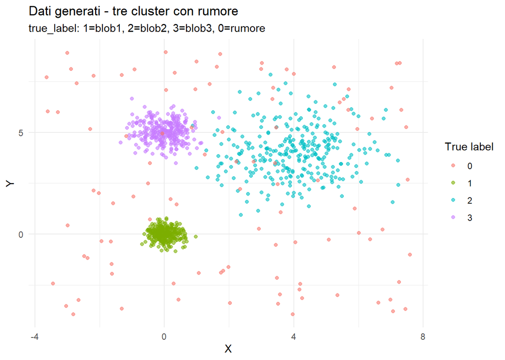

```r
library(ggplot2)

ggplot(blobs, aes(x = x, y = y, color = factor(true_label))) +
  geom_point(alpha = 0.6, size = 1.5) +
  labs(
    title = "Dati generati - tre cluster con rumore",
    subtitle = "true_label: 1=blob1, 2=blob2, 3=blob3, 0=rumore",
    x = "X",
    y = "Y",
    color = "True label"
  ) +
  theme_minimal()
```

## 💥 Risposta

I dati generati sono composti da **300 punti per ciascuno dei tre cluster** (blob1, blob2, blob3) e **100 punti di rumore** distribuiti uniformemente.

- **blob1**: centrato in (0,0) con bassa variabilità (sd = 0.3)
- **blob2**: centrato in (4,4) con variabilità maggiore (sd = 1.2)
- **blob3**: centrato in (0,5) con variabilità intermedia (sd = 0.5)
- **rumore**: punti sparsi uniformemente nell’area [-4,8] × [-4,9]

Dal grafico si osservano tre addensamenti ben distinti, con il blob2 che appare più sparso e il blob1 molto compatto. I punti di rumore sono distribuiti in tutta l’area, anche tra i cluster.

### 🔹 Punto b)

Applicare l’algoritmo DBSCAN dopo aver opportunamente scelto `minPts` e `eps`.

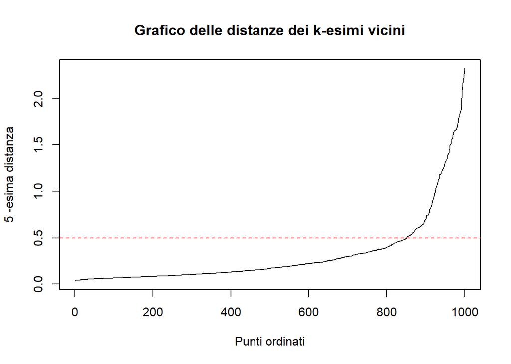

```r
library(dbscan)

# Scelta di eps e minPts
# Regola pratica: minPts >= dimensione + 1 = 3 (dati 2D)
minPts <- 5

# Per scegliere eps, uso il grafico delle distanze dei k-esimi vicini
k_dist <- kNNdist(blobs[, c("x", "y")], k = minPts)
plot(sort(k_dist), type = "l",
     xlab = "Punti ordinati", ylab = paste(minPts, "-esima distanza"),
     main = "Grafico delle distanze dei k-esimi vicini")
abline(h = 0.5, col = "red", lty = 2)
```

```r
# Dal grafico, scelgo eps = 0.5 (punto di flesso)
eps <- 0.5

# Applico DBSCAN
dbscan_model <- dbscan(blobs[, c("x", "y")], eps = eps, minPts = minPts)

cat("Risultati DBSCAN:\n")
```

```
## Risultati DBSCAN:
```

```r
print(table(dbscan_model$cluster))
```

```
##
##   0   1   2   3   4
## 101 301 589   5   4
```

```r
cat("\nNumero di cluster trovati:", max(dbscan_model$cluster), "\n")
```

```
##
## Numero di cluster trovati: 4
```

```r
cat("Numero di punti di rumore:", sum(dbscan_model$cluster == 0), "\n")
```

```
## Numero di punti di rumore: 101
```